# Homework 5

Evan Hall

02/05/2020

# Load packages

Save any data frames generated to curated_data directory, save all plots to figures directory. Based on assumptions, clearly state which statistical test will be used and why. Include any statistics (p- or R-values) as comments after the tests.

# Question 1

Use the SCFA wide dataframe from Lab 5. Check assumptions, conduct statistical tests, make a plot, to answer the question, “Which supplement causes the greatest increase in acetate concentrations?”

```r
# import and filter data set (q1_df)
q1_df <- read_delim(file = "raw_data/scfa_wide.txt",
                        delim = "\t", escape_double = FALSE,
                        trim_ws = TRUE, na=c("NA"),
                        col_names = TRUE,
                        col_types = cols(participant_id = col_character(),
                                         semester = col_character(),
                                         supplement_consumed = col_character(),
                                         quantity_compliant = col_character(),
                                         frequency = col_character(),
                                         acetate_delta = col_double(),
                                         butyrate_delta = col_double(),
                                         propionate_delta = col_double())) %>%
  filter(semester != "Winter2015",
         quantity_compliant != "no")
```

```r
# check assumptions
# Variance
bartlett.test(acetate_delta ~ supplement_consumed, data = q1_df)
```

```
##
##  Bartlett test of homogeneity of variances
##
## data:  acetate_delta by supplement_consumed
## Bartlett's K-squared = 22.886, df = 11, p-value = 0.01834
```

```r
# ALTERNATIVE
```

```r
# conduct statistical test
aov_results <- aov(acetate_delta ~ supplement_consumed, data = q1_df)
summary(aov_results)
```

```
##                      Df Sum Sq Mean Sq F value Pr(>F)
## supplement_consumed  11   4818   438.0   0.994  0.451
## Residuals           383 168829   440.8
## 4 observations deleted due to missingness
```

```r
tuk_delta <- tidy(TukeyHSD(aov_results)) %>%
  mutate(adj.p.value = round(adj.p.value, digits = 2)) #round resulting p-values
 #filter Tukey output for significant results
write_delim(tuk_delta, path = "curated_data/tukey_result_acetate_delta.txt",
            delim = "\t", col_names = TRUE, quote = FALSE)
```

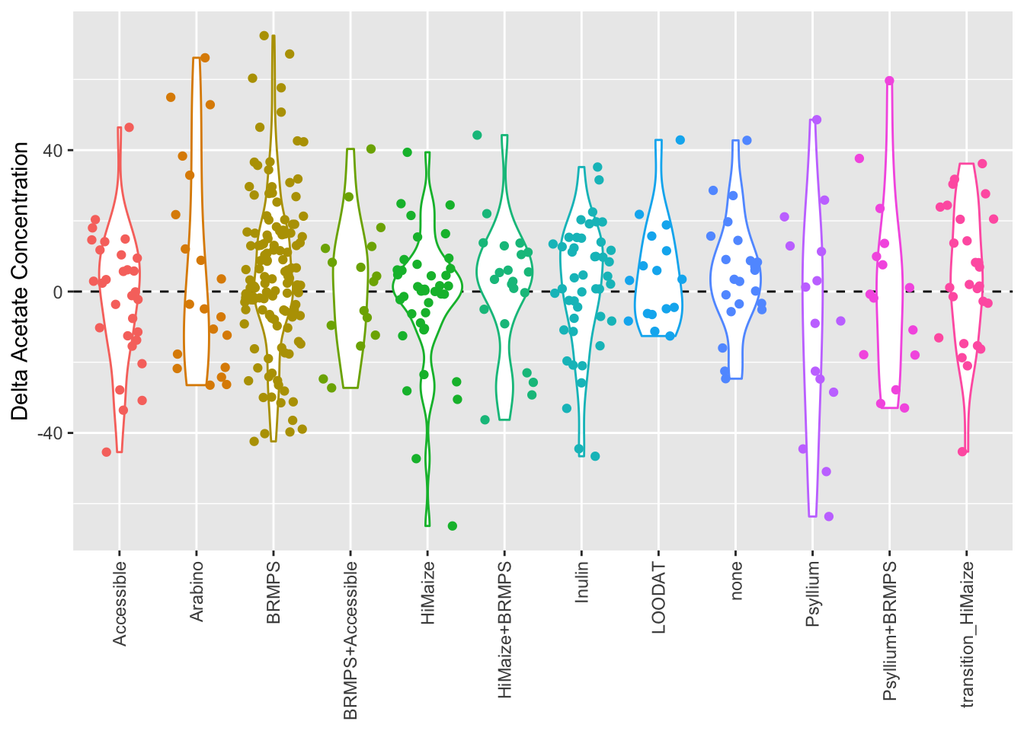

```r
# make and save plot (q1_plot)
q1_plot <-  q1_df %>%
  filter(semester != "Winter2015",
         quantity_compliant != "no")
# plot
q1_df %>%
  ggplot(aes(x = supplement_consumed,
             y = acetate_delta,
             color = supplement_consumed)) +
  geom_hline(yintercept = 0, linetype = "dashed") +
  geom_violin() +
  geom_jitter() +
  xlab(NULL) +
  ylab("Delta Acetate Concentration") +
  theme(legend.position = "none",
        axis.text.x = element_text(angle = 90, vjust = 0.5, hjust = 1))
```

```r
# run the test
kruskal.test(supplement_consumed ~ acetate_delta, q1_df)
```

```
##
##  Kruskal-Wallis rank sum test
##
## data:  supplement_consumed by acetate_delta
## Kruskal-Wallis chi-squared = 390.3, df = 391, p-value = 0.5005
```

```r
write_delim(q1_df, path = "figures/q1.txt",
            delim = "\t", col_names = TRUE, quote = FALSE)
```

What are your conclusions regarding the reseach question? Because the p-value is extremely high .5005 at the .05 alpha level, then we would fail to reject the null hypothesis. There is no difference any of the variables that influence the change in acetate concentration.